# Run code snippets

Kotlin code is typically organized into projects with which you work in an IDE, a text editor, or another tool. However, if you want to quickly see how a function works or find an expression's value, there's no need to create a new project and build it. Check out these three handy ways to run Kotlin code instantly in different environments:

- Scratch files in the IDE.
- Kotlin Playground in the browser.
- ki shell in the command line.

## IDE: scratches

IntelliJ IDEA and Android Studio support Kotlin [scratch files](https://www.jetbrains.com/help/idea/kotlin-repl.html#efb8fb32).

Scratch files (or just scratches) let you create code drafts in the same IDE window as your project and run them on the fly. Scratches are not tied to projects; you can access and run all your scratches from any IntelliJ IDEA window on your OS.

To create a Kotlin scratch, click File | New | Scratch File and select the Kotlin type.

Syntax highlighting, auto-completion, and other IntelliJ IDEA code editing features are supported in scratches. There's no need to declare the `main()` function – all the code you write is executed as if it were in the body of `main()`.

Once you have finished writing your code in a scratch, click Run. The execution results will appear in the lines opposite your code.

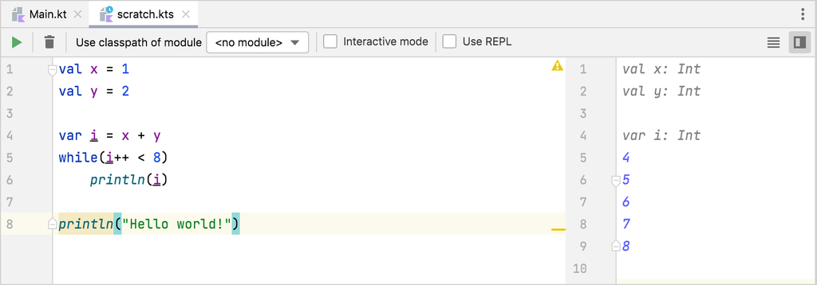

### Interactive mode

The IDE can run code from scratches automatically. To get execution results as soon as you stop typing, switch on Interactive mode.

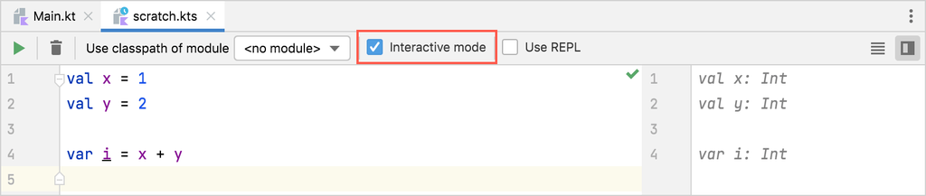

### Use modules

You can use classes or functions from a Kotlin project in your scratches.

To use classes or functions from a project in a scratch, import them into the scratch file with the `import` statement, as usual. Then write your code and run it with the appropriate module selected in the Use classpath of module list.

Scratches use the compiled versions of connected modules. So, if you modify a module's source files, the changes will propagate to scratches when you rebuild the module. To rebuild the module automatically before each run of a scratch, select Make module before Run.

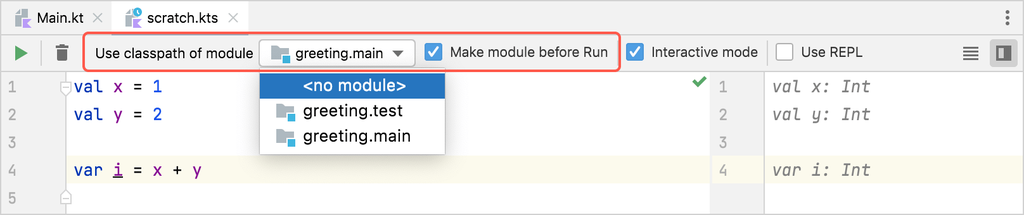

## Browser: Kotlin Playground

[Kotlin Playground](https://play.kotlinlang.org/) is an online application for writing, running, and sharing Kotlin code in your browser.

### Write and edit code

In the Playground's editor area, you can write code just as you would in a source file:

- Add your own classes, functions, and top-level declarations in an arbitrary order.
- Write the executable part in the body of the `main()` function.

As in typical Kotlin projects, the `main()` function in the Playground can have the `args` parameter or no parameters at all. To pass program arguments upon execution, write them in the Program arguments field.

[figure not shown]

The Playground highlights the code and shows code completion options as you type. It automatically imports declarations from the standard library and `kotlinx.coroutines`.

### Choose execution environment

The Playground provides ways to customize the execution environment:

- Multiple Kotlin versions, including available previews of future versions.
- Multiple backends to run the code in: JVM, JS (legacy or IR compiler, or Canvas), or JUnit.

[figure not shown]

For JS backends, you can also see the generated JS code.

[figure not shown]

### Share code online

Use the Playground to share your code with others – click Copy link and send it to anyone you want to show the code to.

You can also embed code snippets from the Playground into other websites and even make them runnable. Click Share code to embed your sample into any web page or into a [Medium](https://medium.com/) article.

[figure not shown]

## Command line: ki shell

The [ki shell](https://github.com/Kotlin/kotlin-interactive-shell) (Kotlin Interactive Shell) is a command-line utility for running Kotlin code in the terminal. It's available for Linux, macOS, and Windows.

The ki shell provides basic code evaluation capabilities, along with advanced features such as:

- code completion
- type checks
- external dependencies
- paste mode for code snippets
- scripting support

See the [ki shell GitHub repository](https://github.com/Kotlin/kotlin-interactive-shell) for more details.

### Install and run ki shell

To install the ki shell, download the latest version of it from [GitHub](https://github.com/Kotlin/kotlin-interactive-shell) and unzip it in the directory of your choice.

On macOS, you can also install the ki shell with Homebrew by running the following command:

```
brew install ki
```

To start the ki shell, run `bin/ki.sh` on Linux and macOS (or just `ki` if the ki shell was installed with Homebrew) or `bin\ki.bat` on Windows.

Once the shell is running, you can immediately start writing Kotlin code in your terminal. Type `:help` (or `:h`) to see the commands that are available in the ki shell.

### Code completion and highlighting

The ki shell shows code completion options when you press Tab. It also provides syntax highlighting as you type. You can disable this feature by entering `:syntax off`.

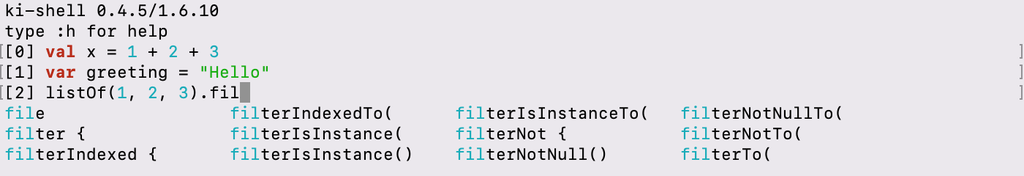

When you press Enter, the ki shell evaluates the entered line and prints the result. Expression values are printed as variables with auto-generated names like `res*`. You can later use such variables in the code you run. If the construct entered is incomplete (for example, an `if` with a condition but without the body), the shell prints three dots and expects the remaining part.

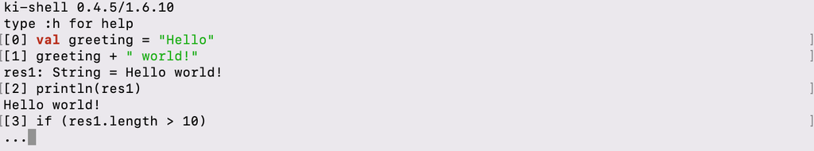

### Check an expression's type

For complex expressions or APIs that you don't know well, the ki shell provides the `:type` (or `:t`) command, which shows the type of an expression:

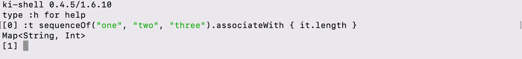

### Load code

If the code you need is stored somewhere else, there are two ways to load it and use it in the ki shell:

- Load a source file with the `:load` (or `:l`) command.
- Copy and paste the code snippet in paste mode with the `:paste` (or `:p`) command.

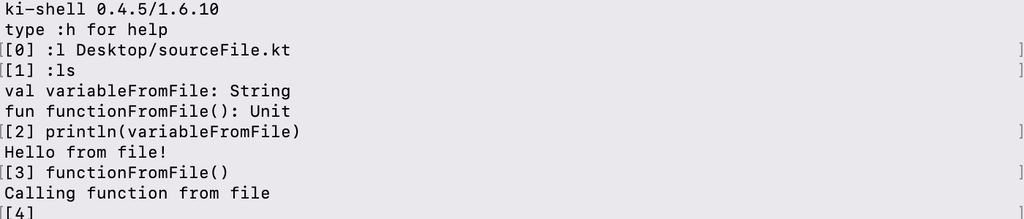

The `ls` command shows available symbols (variables and functions).

### Add external dependencies

Along with the standard library, the ki shell also supports external dependencies. This lets you try out third-party libraries in it without creating a whole project.

To add a third-party library in the ki shell, use the `:dependsOn` command. By default, the ki shell works with Maven Central, but you can use other repositories if you connect them using the `:repository` command:

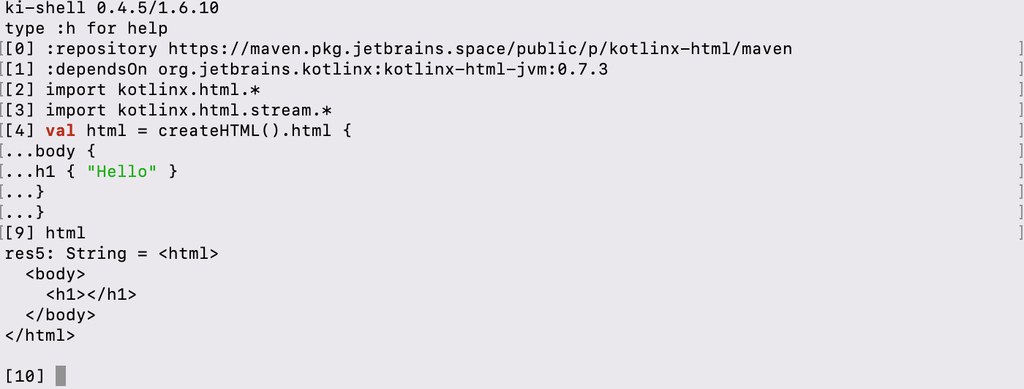